# Data Types

Thomas Manke

26 Sep 2017

# From Vectors to Matrices

```r
v=1:20
str(v)    # str helps to understand the structure of an object
```

```
##  int [1:20] 1 2 3 4 5 6 7 8 9 10 ...
```

```r
M=matrix(v, ncol=5)
M         # show the whole object.
```

```
##      [,1] [,2] [,3] [,4] [,5]
## [1,]    1    5    9   13   17
## [2,]    2    6   10   14   18
## [3,]    3    7   11   15   19
## [4,]    4    8   12   16   20
```

```r
str(M)    # more concise summary, especially for large objects
```

```
##  int [1:4, 1:5] 1 2 3 4 5 6 7 8 9 10 ...
```

```r
class(M)  # class helps to understand which functions maybe used
```

```
## [1] "matrix"
```

```r
typeof(M) # matrix entries always have a single data type
```

```
## [1] "integer"
```

# Added information for matrices

```r
dim(M)
nrow(M)
ncol(M)
length(M)
```

# Matrices != Vectors

```r
is.vector(M)
```

```
## [1] FALSE
```

```r
is.vector(M[,1]) # matrix is a collection of vectors
```

```
## [1] TRUE
```

```r
is.vector(v)
```

```
## [1] TRUE
```

```r
dim(v)           # dim() is not defined for vectors
```

```r
nrow(v)          # nrow() is not defined for vectors
```

```r
dim(v)=c(4,5)    # another way to convert vector to matrix
v
```

```
##      [,1] [,2] [,3] [,4] [,5]
## [1,]    1    5    9   13   17
## [2,]    2    6   10   14   18
## [3,]    3    7   11   15   19
## [4,]    4    8   12   16   20
```

```r
is.vector(v)
```

```
## [1] FALSE
```

```r
class(v)
```

```
## [1] "matrix"
```

```r
nrow(v)
```

```
## [1] 4
```

```r
dim(v)=c(2,10)  # dim can be redefined to change shape of matrix
```

**Task**: Try to understand what happens here:

```r
# try: dim(v)=c(3,7)
M=matrix(v,ncol=7)
dim(v)=c(2,2,5)
class(v)
```

```
## [1] "array"
```

**Task**: Convert the first 9 square numbers into a 3x3 matrix:

```
##      [,1] [,2] [,3]
## [1,]    1   16   49
## [2,]    4   25   64
## [3,]    9   36   81
```

# Combining and appending matrices

```r
M=matrix(v,nrow=4)
M
```

```
##      [,1] [,2] [,3] [,4] [,5]
## [1,]    1    5    9   13   17
## [2,]    2    6   10   14   18
## [3,]    3    7   11   15   19
## [4,]    4    8   12   16   20
```

```r
Mr=rbind(M,1:5)
Mr
```

```
##      [,1] [,2] [,3] [,4] [,5]
## [1,]    1    5    9   13   17
## [2,]    2    6   10   14   18
## [3,]    3    7   11   15   19
## [4,]    4    8   12   16   20
## [5,]    1    2    3    4    5
```

```r
Mc=cbind(M,1:4)
Mc
```

```
##      [,1] [,2] [,3] [,4] [,5] [,6]
## [1,]    1    5    9   13   17    1
## [2,]    2    6   10   14   18    2
## [3,]    3    7   11   15   19    3
## [4,]    4    8   12   16   20    4
```

# Naming Matrices

What are the following commands doing? Inspect matrix $M$ before and after.

```r
rownames(M)=letters[1:nrow(M)]
colnames(M)=LETTERS[1:ncol(M)]
```

# Powerful Subsetting

R has a number of ways to access subsets of data very efficiently:

```r
M
```

```
##   A B  C  D  E
## a 1 5  9 13 17
## b 2 6 10 14 18
## c 3 7 11 15 19
## d 4 8 12 16 20
```

```r
M[1:2,c(2,4)]                  # subsetting by index
```

```
##   B  D
## a 5 13
## b 6 14
```

```r
M[c("c","a"),c("D","A","E")]   # subsetting by name
```

```
##    D A  E
## c 15 3 19
## a 13 1 17
```

```r
M[,-3]                         # subsetting by exclusion
```

```
##   A B  D  E
## a 1 5 13 17
## b 2 6 14 18
## c 3 7 15 19
## d 4 8 16 20
```

**Task**: Extract the submatrix of M where the second column has only even entries.  
**Tip**: Look at an example of the modulo operator first; example(“%%”)

```
##   A B  C  D  E
## b 2 6 10 14 18
## d 4 8 12 16 20
```

# New functionalities for matrices

Execute and understand the following expressions

```r
t(M)
v=as.vector(M)
summary(v)
summary(M)

det(M)
det(M[1:2,3:4])
```

# Matrix Magic

```r
S=outer(1:3, 4:6)  # what is this function doing?
S
```

```
##      [,1] [,2] [,3]
## [1,]    4    5    6
## [2,]    8   10   12
## [3,]   12   15   18
```

```r
diag(S)
```

```
## [1]  4 10 18
```

```r
upper.tri(S)       # what type/class of matrix is this ?
```

```
##       [,1]  [,2]  [,3]
## [1,] FALSE  TRUE  TRUE
## [2,] FALSE FALSE  TRUE
## [3,] FALSE FALSE FALSE
```

```r
S[upper.tri(S)]=0  # subsetting by truth values. What will be the result?
```

# Data Frames

Data frames superseed matrices. They relax the requirement of having the same data type for all entries. This can be considered the R-equivalent of an EXCEL table. Data frames collect nrow *observations* for ncol *variables*

```r
D=data.frame(x=1:9,l=letters[1:9], b=1:9<5)
class(D)
```

```
## [1] "data.frame"
```

```r
str(D)   # structure of object D
```

```
## 'data.frame':    9 obs. of  3 variables:
##  $ x: int  1 2 3 4 5 6 7 8 9
##  $ l: Factor w/ 9 levels "a","b","c","d",..: 1 2 3 4 5 6 7 8 9
##  $ b: logi  TRUE TRUE TRUE TRUE FALSE FALSE ...
```

```r
head(D)  # a very useful first glance at the data frame
```

```
##   x l     b
## 1 1 a  TRUE
## 2 2 b  TRUE
## 3 3 c  TRUE
## 4 4 d  TRUE
## 5 5 e FALSE
## 6 6 f FALSE
```

```r
tail(D,n=3)
```

```
##   x l     b
## 7 7 g FALSE
## 8 8 h FALSE
## 9 9 i FALSE
```

```r
rownames(D)
```

```
## [1] "1" "2" "3" "4" "5" "6" "7" "8" "9"
```

```r
colnames(D)
```

```
## [1] "x" "l" "b"
```

```r
dim(D)            # similar to matrices
```

```
## [1] 9 3
```

```r
length(D)         # = ncol(D)
```

```
## [1] 3
```

```r
as.data.frame(M)  # yet another conversion: matrix --> data.frame
```

```
##   A B  C  D  E
## a 1 5  9 13 17
## b 2 6 10 14 18
## c 3 7 11 15 19
## d 4 8 12 16 20
```

# Accessing Data Frames

The general access to elements is as for vectors, but there are also new ways

```r
D
```

```
##   x l     b
## 1 1 a  TRUE
## 2 2 b  TRUE
## 3 3 c  TRUE
## 4 4 d  TRUE
## 5 5 e FALSE
## 6 6 f FALSE
## 7 7 g FALSE
## 8 8 h FALSE
## 9 9 i FALSE
```

```r
D[1:3, ]
```

```
##   x l    b
## 1 1 a TRUE
## 2 2 b TRUE
## 3 3 c TRUE
```

```r
D[6:9, -2]
```

```
##   x     b
## 6 6 FALSE
## 7 7 FALSE
## 8 8 FALSE
## 9 9 FALSE
```

```r
D$x          # access by column name
```

```
## [1] 1 2 3 4 5 6 7 8 9
```

```r
typeof(D$x)
```

```
## [1] "integer"
```

```r
typeof(D$l)
```

```
## [1] "integer"
```

```r
D$b[3:6]
```

```
## [1]  TRUE  TRUE FALSE FALSE
```

# Lists

List extends the data frame: different “columns” can have different length

```r
L=list(x=1:9,l=letters[1:3], b=1:20<10)
class(L)
```

```
## [1] "list"
```

```r
str(L)
```

```
## List of 3
##  $ x: int [1:9] 1 2 3 4 5 6 7 8 9
##  $ l: chr [1:3] "a" "b" "c"
##  $ b: logi [1:20] TRUE TRUE TRUE TRUE TRUE TRUE ...
```

```r
head(L,2)
```

```
## $x
## [1] 1 2 3 4 5 6 7 8 9
##
## $l
## [1] "a" "b" "c"
```

```r
summary(L)
```

```
##   Length Class  Mode
## x  9     -none- numeric
## l  3     -none- character
## b 20     -none- logical
```

```r
dim(L)
```

```r
length(L)
```

```
## [1] 3
```

```r
names(L)
```

```
## [1] "x" "l" "b"
```

## List can be recursive

**Task**: Describe the items in the following list. What is the length of L? How many names does L have?

```r
L=list(x=1:9,l=list(i=1,v=c(10,20,30),m=outer(1:3,1:3)), b=1:20<10)
```

## List Access: Options and Confusions

```r
L$x
L[[1]]
L[["x"]]
L[["x"]][3]
L$l$v[2]
```

**Task**: what happens with “which”?

```r
which(L[[1]]!=2)
```

```
## [1] 1 3 4 5 6 7 8 9
```

```r
which(L[[3]])
```

```
## [1] 1 2 3 4 5 6 7 8 9
```

# Summary: Data Types

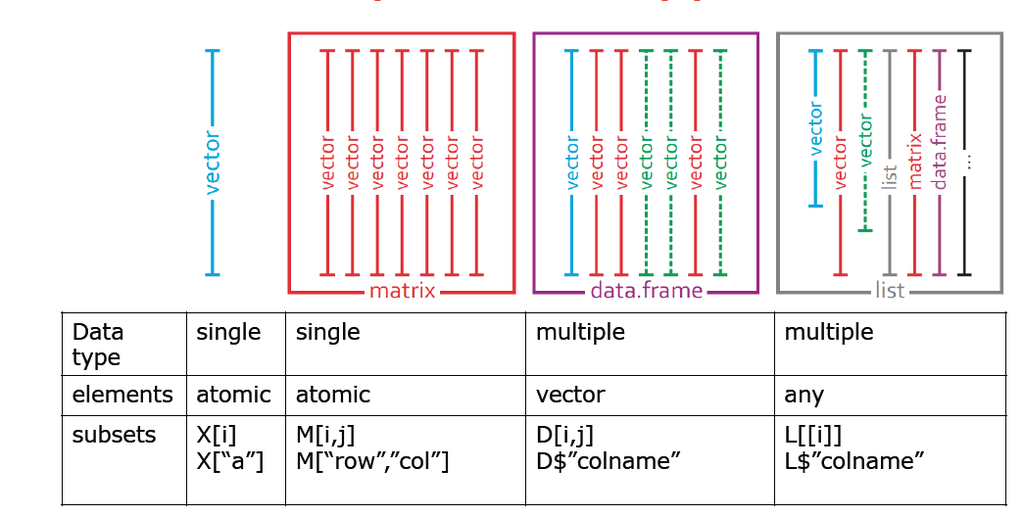

This image is adopted from Michael Stadler (FMI).